# ReliaLearnR: Learning Modules for Reliability Analysis

31 August 2025

# Statement of Need

Reliability analysis is an important aspect of engineering that focuses on ensuring systems perform as expected over time. Key components of reliability analysis include life data analysis, reliability, availability, and maintainability (RAM) analysis, and reliability testing. These concepts are essential for engineers and professionals involved in product design, manufacturing, and maintenance. However, many learning resources for these topics rely on proprietary software, which can be expensive and inaccessible to students and early-career professionals.

`ReliaLearnR` (Govan 2025) addresses this gap by providing an open-source framework for learning reliability analysis using R (R Core Team 2023), a widely-used programming language for statistical computing and data analysis. The primary objective of this project is to introduce fundamental concepts of reliability analysis while providing an open-source alternative for analyzing reliability data. The target audience for this project includes engineering students and professionals interested in learning the fundamentals of reliability analysis.

# Design

`ReliaLearnR` is written in R (R Core Team 2023) and utilizes `WeibullR` (Silkworth and Symynck 2022) for Life Data Analysis (Abernethy 1993), `WeibullR.alt` (Silkworth 2022) for Accelerated Life Testing (Silkworth 2022), `ReliaGrowR` (Govan 2024) for Reliability Growth Analysis, and `learnr` (Aden-Buie et al. 2023), a framework for building interactive learning modules.

The learning modules are designed to be interactive and engaging, with a focus on practical applications. Each module includes a mix of instructional content, code examples, and exercises to reinforce learning. The modules are self-paced, allowing learners to progress at their own speed.

The original learning modules were provided in a series of workshops, where each workshop covered a specific module over a 1-2 hour period. These workshops were designed to be completed in a classroom setting with an instructor. The current version of the modules has been adapted for self-paced learning, but they can still be used in a classroom setting with an instructor.

To adopt the modules for classroom use, instructors can either access them via the project website or install the package and use the functions directly. Instructors can also modify the modules to fit their specific needs, as the source code is available on the project repository.

# Usage

The package includes three interactive learning modules, which can be run locally or hosted on a web server. Users can run the modules in any R environment by calling the `ram()`, `lda()`, or `rt()` functions.

`ram()` is a quick reference for common Reliability, Availability, and Maintainability (RAM) concepts. The learning objectives include defining key reliability metrics, including reliability, availability, and failure rate, Describing the significance of MTTR, MTTF, and MTBF in reliability engineering, calculating probability of failure using given reliability data, interpreting $B_n$ or $L_n$ life values in the context of product reliability, differentiating between different reliability measures.

`lda()` provides an introduction to Life Data Analysis. The learning objectives include describing the purpose of Weibull analysis in reliability engineering, differentiating between types of data censoring, including right-censored and interval-censored data, differentiating between different Weibull models (2-parameter Weibull, 3-parameter Weibull, and Weibayes, applying Median Rank Regression (MRR) and Maximum Likelihood Estimation (MLE) estimation methods to sample datasets, interpreting results using plotting methods, including probability plots and contour plots.

`rt()` provides an introduction to Reliability Testing. The learning objectives include defining key reliability growth concepts, including Crow-AMSAA and Duane models, fitting a reliability growth model to real-world data using R, interpreting reliability growth plots and identifying trends, applying the Crow-AMSAA model to assess reliability growth, explaining fundamental concepts of accelerated life testing, including the use of Arrhenius and Power Law Models, conducting an accelerated life test with real-world datasets, utilizing R for analysis, analyzing plots that illustrate the relationships in accelerated life testing, identifying key patterns and data trends, and utilizing Arrhenius and Power Law models to evaluate the impact of stress factors on product reliability.

The modules can also be accessed in a browser at paulgovan.shinyapps.io/RAMAnalysis/, paulgovan.shinyapps.io/LifeDataAnalysis/, and paulgovan.shinyapps.io/ReliabilityTesting/.

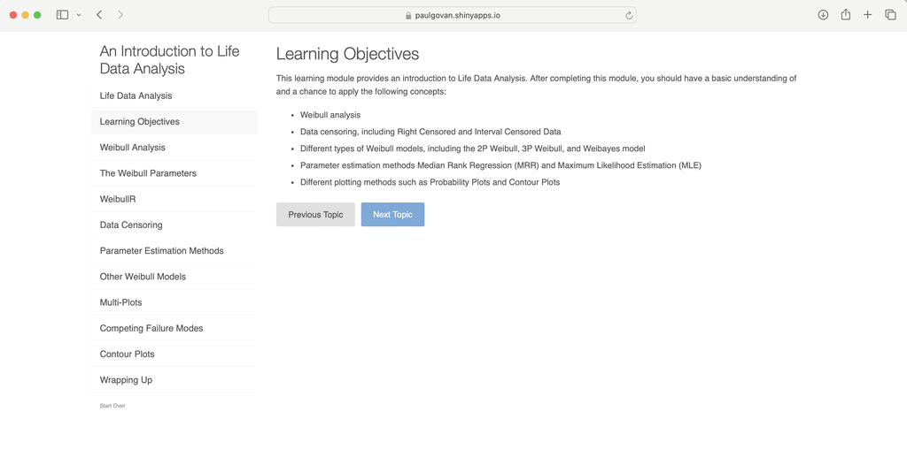

The package also includes several helper functions for common RAM calculations. These functions make it easy to apply the concepts covered in the RAM module.

- `rel()` - reliability function
- `avail()` - availability function
- `mttf()` - mean time to failure
- `mtbf()` - mean time between failure
- `fr()` - failure rate

The project documentation includes installation instructions for `ReliaLearnR` and the required dependencies, examples of running the programs, and references to previous work used to build the modules. The documentation also references more resources for users interest in learning more. These resources include `ReliaPlotR` (Govan 2023a), an R package for interactive reliability analysis plots, and `ReliaShinR` (Govan 2023b), a shiny (Chang et al. 2022) web application for reliability analysis.

Contributions are welcome from the community. Users can submit pull requests, report issues, or suggest enhancements through the repository, which includes contributing guidelines.

# Motivation

This project began as an effort to build upon a reliability program developed at a major technology company. The original program proved to provide a strong foundation, providing a structured learning opportunity that helped many early-career professionals understand and apply the fundamental concepts of reliability engineering. Over time, however, the proprietary nature of the program limited accessibility and adaptability.

Recognizing the importance of keeping reliability learning both relevant and accessible, this project was initiated to create an open-source framework for teaching reliability analysis. By leveraging this framework, this project aims to reach a broader audience, encourage collaboration, and ensure that learning resources can evolve as needs and priorities change.

# Acknowledgements

The author acknowledges the creators of the original Reliability Program that inspired this project.

# References

Abernethy, Robert B. 1993. *The New Weibull Handbook*. R.B. Abernethy; Distributed by GULF Pub. Co. https://cir.nii.ac.jp/crid/1130282270976797824.

Aden-Buie, Garrick, Barret Schloerke, JJ Allaire, and Alexander Rossell Hayes. 2023. *Learnr: Interactive Tutorials for r*. https://doi.org/10.32614/CRAN.package.learnr.

Chang, Winston, Joe Cheng, JJ Allaire, Carson Sievert, Barret Schloerke, Yihui Xie, Jeff Allen, Jonathan McPherson, Alan Dipert, and Barbara Borges. 2022. *Shiny: Web Application Framework for r*. https://doi.org/10.32614/CRAN.package.shiny.

Govan, Paul. 2023a. *ReliaPlotR: Interactive Reliability Analysis Plots*. https://doi.org/10.32614/CRAN.package.ReliaPlotR.

———. 2023b. *ReliaShiny: A ’Shiny’ App for Reliability Analysis*. https://doi.org/10.32614/CRAN.package.ReliaShiny.

———. 2024. *ReliaGrowR: Reliability Growth Analysis*. https://doi.org/10.32614/CRAN.package.ReliaGrowR.

———. 2025. *ReliaLearnR: Learning Modules for Reliability Analysis*. https://doi.org/10.32614/CRAN.package.ReliaLearnR.

R Core Team. 2023. *R: A Language and Environment for Statistical Computing*. Vienna, Austria: R Foundation for Statistical Computing. https://doi.org/10.32614/r.manuals.

Silkworth, David. 2022. *WeibullR.ALT: Accelerated Life Testing Using ’WeibullR’*. https://CRAN.R-project.org/package=WeibullR.ALT.

Silkworth, David, and Jurgen Symynck. 2022. *WeibullR: Weibull Analysis for Reliability Engineering*. https://doi.org/10.32614/CRAN.package.WeibullR.